# Récupération des données et séparation

# Avant/Pendant/Après courses

## Par date

#Trouver le participant median

| numero |
| --- |
| 9 |

#Trouver le participant quantile 0.25

| numero |
| --- |
| 9 |

#trouver le participant quantile 0.75

| numero |
| --- |
| 1 |

#Creation dataframe participant median

#Creation dataframe participant q1

#Creation dataframe participant q3

#Médiane classique

#creation data frame finale

#Graphique avec médiane globale

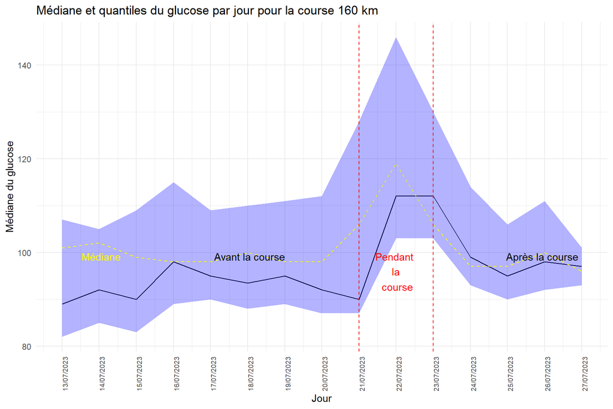

#Graphique sans médiane globale

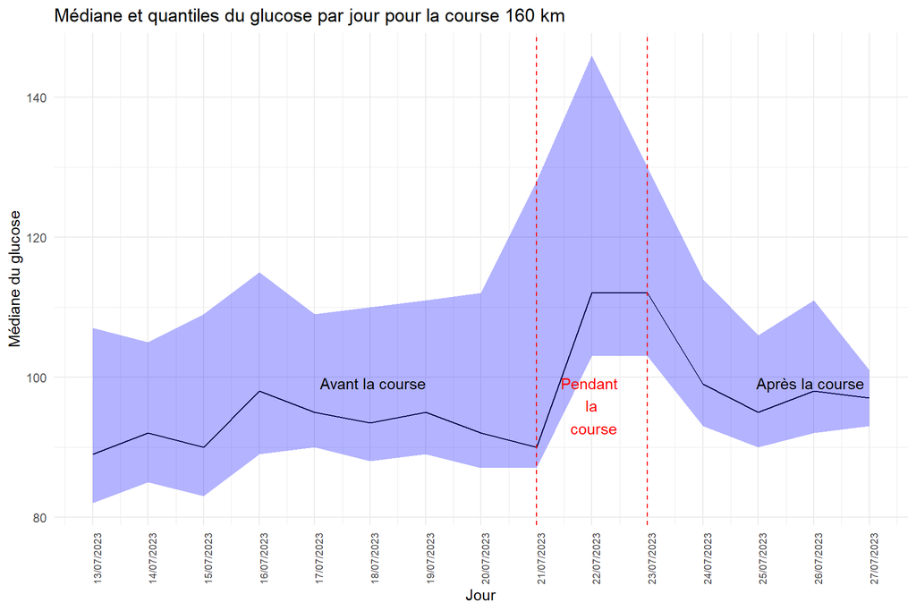

## Par heure

#trouver le participant median

| numero |
| --- |
| 1 |

#trouver le participant quantile 0.25

| numero |
| --- |
| 30 |

#trouver le participant quantile 0.75

| numero |
| --- |
| 1 |

#Creation dataframe participant median

#Creation dataframe participant q1

#Creation dataframe participant q3

#Médiane classique

#creation data frame finale

#Graphique avec médiane globale

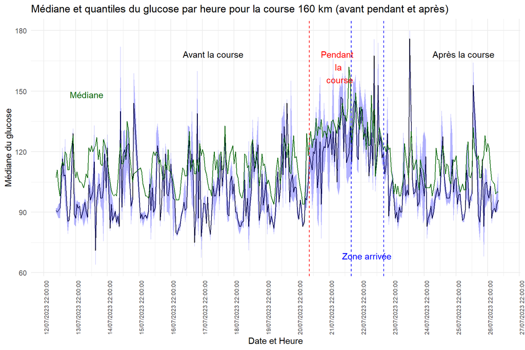

#Graphique sans médiane globale

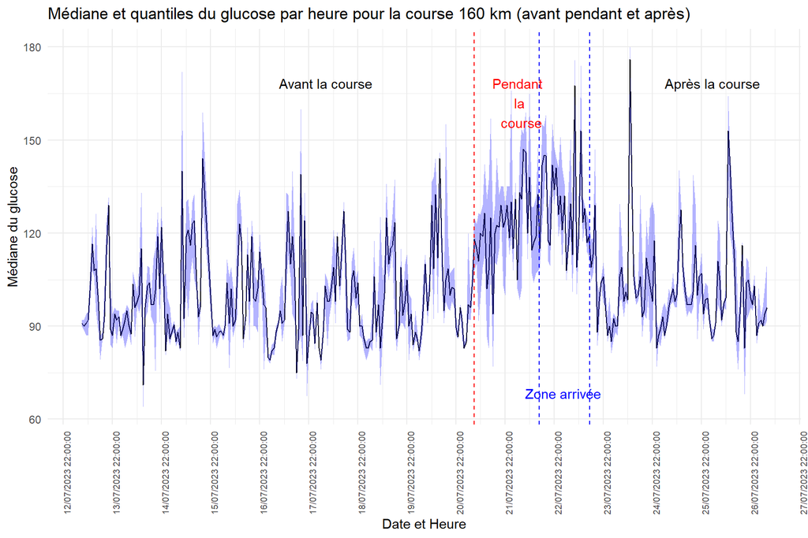

# Pendant la course

#filtrer données de glycémie de la course

##Par heure #trouver le participant median

| numero |
| --- |
| 33 |

#trouver le participant quantile 0.25

| numero |
| --- |
| 36 |

#trouver le participant quantile 0.75

| numero |
| --- |
| 25 |

#Creation dataframe participant median

#Creation dataframe participant q1

#Creation dataframe participant q3

#ajout médiane générale

#ajout q1 générale

#ajout q3 générale

#creation data frame finale

#graphique avec médiane générale ajoutée

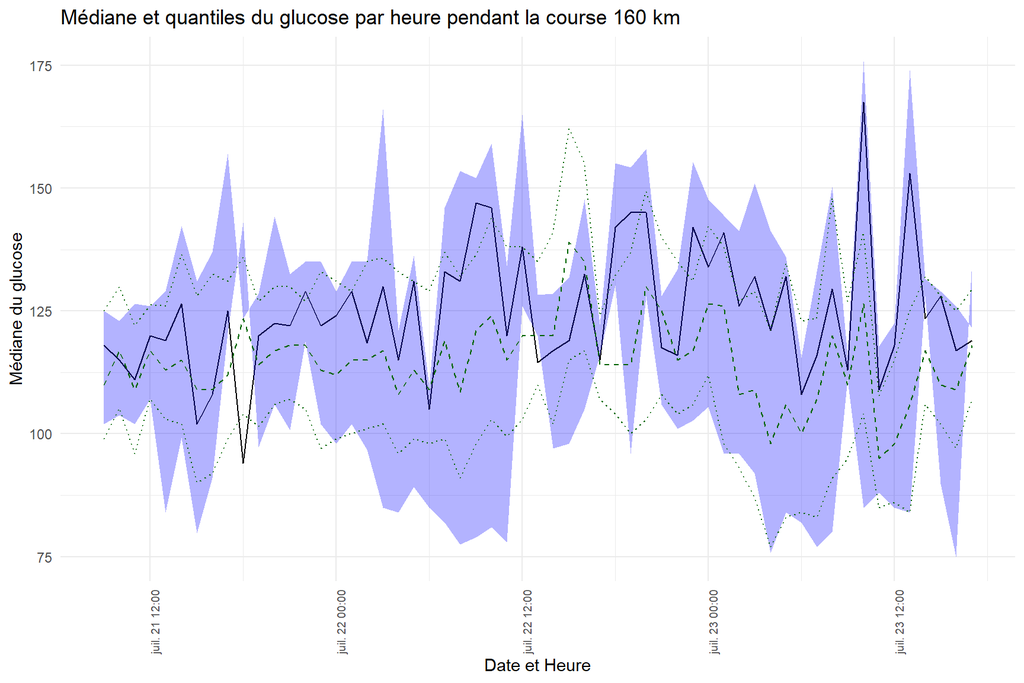

#graphique sans la médiane générale ajoutée

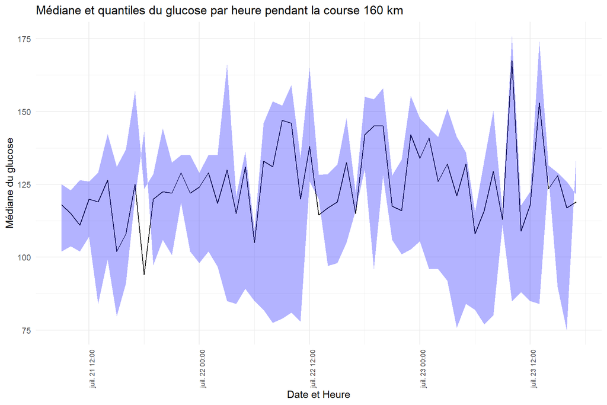

## Par minutes pour chaque participant

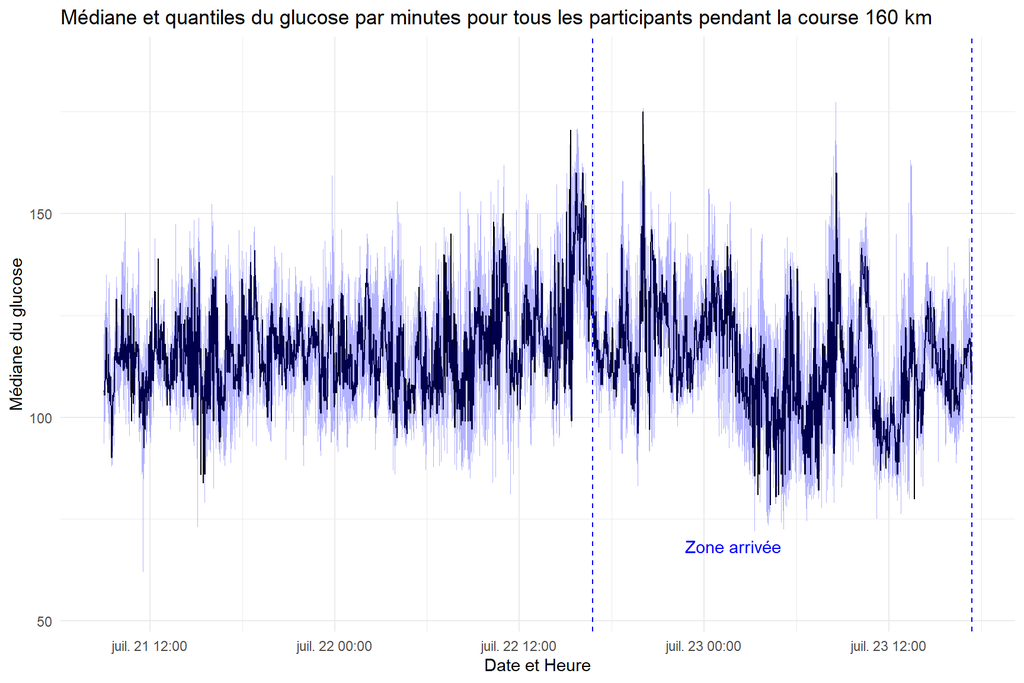

#Par coureur #abandons #Coureur 3

#Coureur 12

#Coureur 15

#Coureur 16

#Coureur 34

#Coureur 35

#Coureur 36

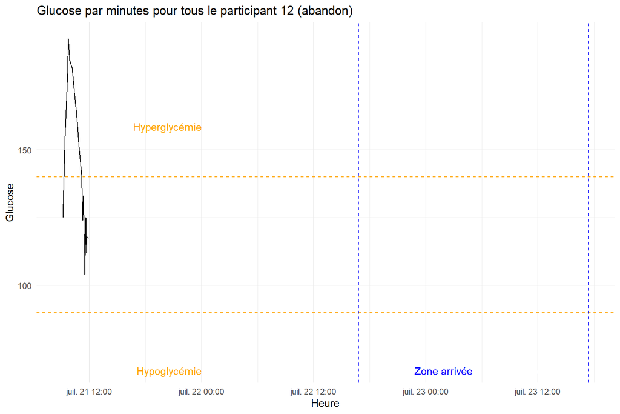

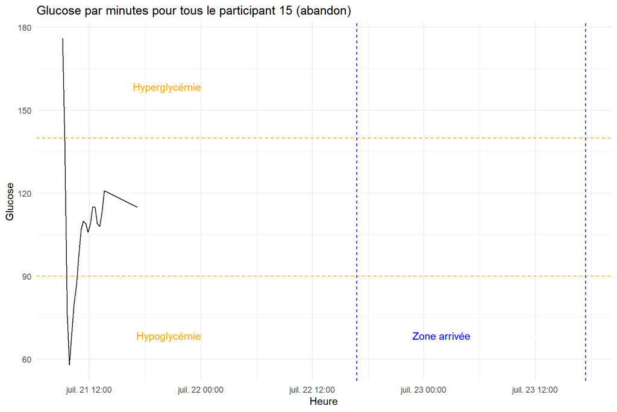

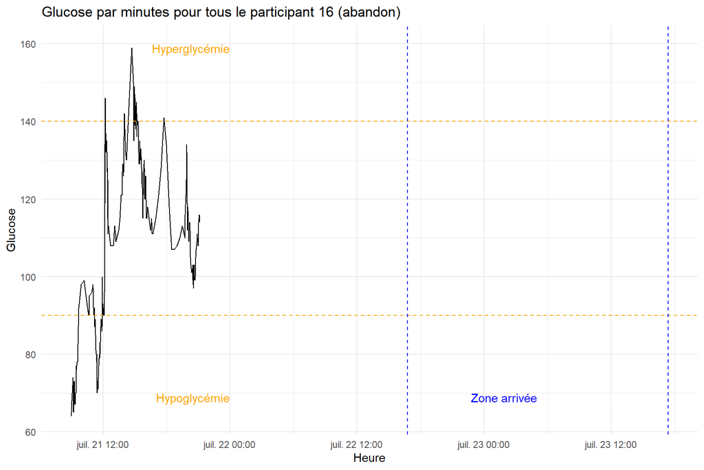

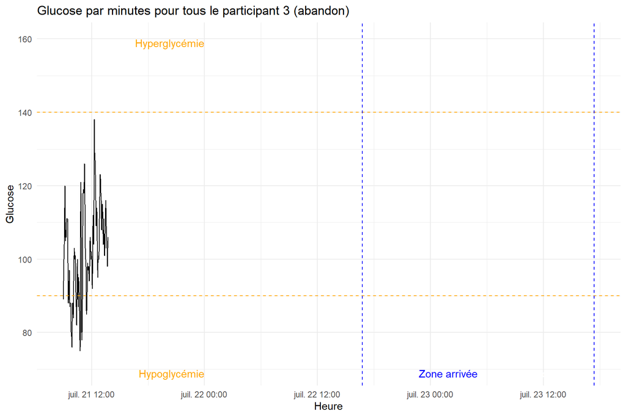

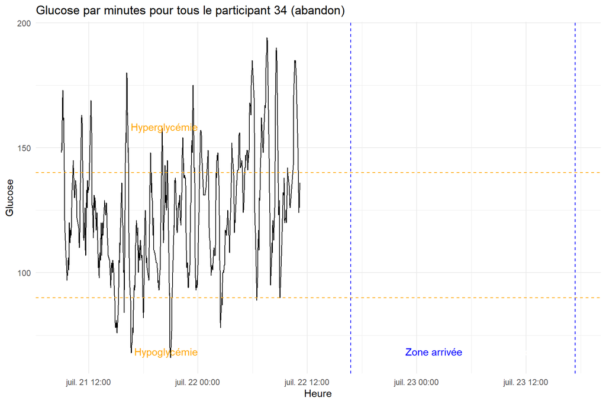

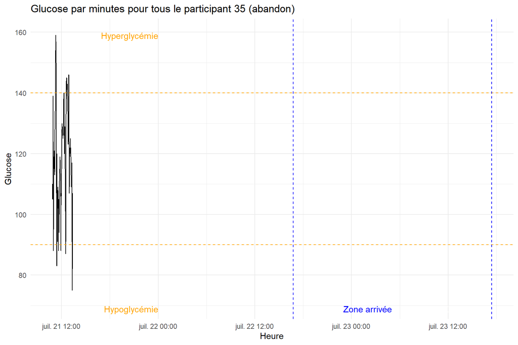

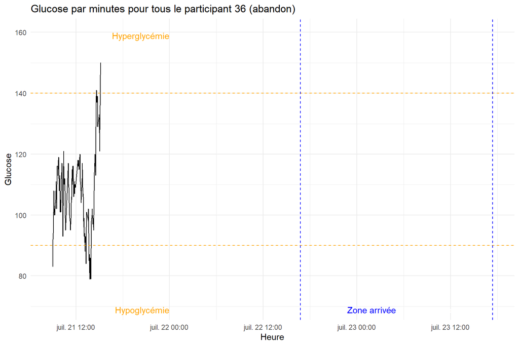

#Finisher #Coureur 1

#Coureur 5

#Coureur 7

#Coureur 8

#Coureur 9

#Coureur 17

#Coureur 20

#Coureur 22

#Coureur 24

#Coureur 25

#Coureur 28

#Coureur 30

#Coureur 33

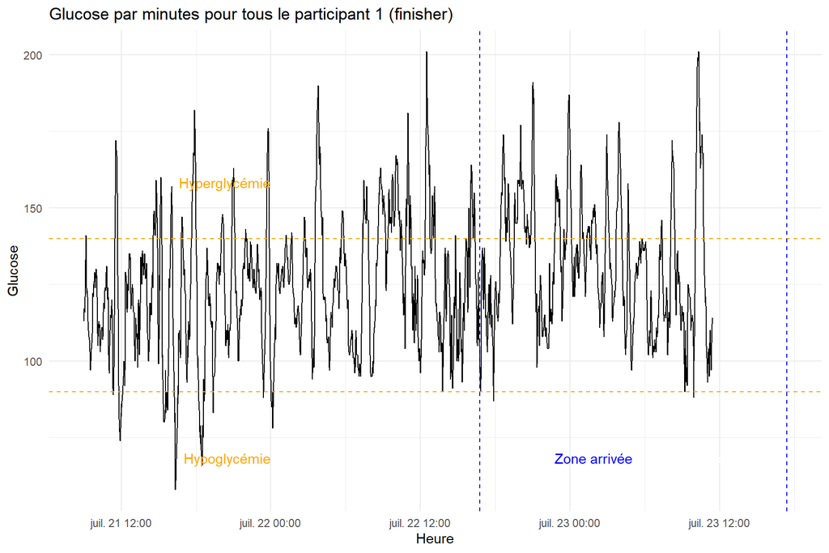

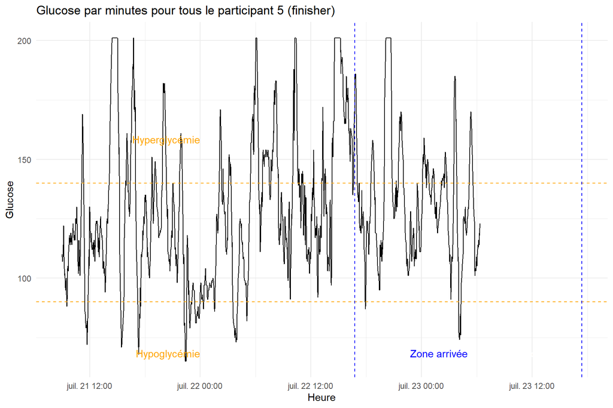

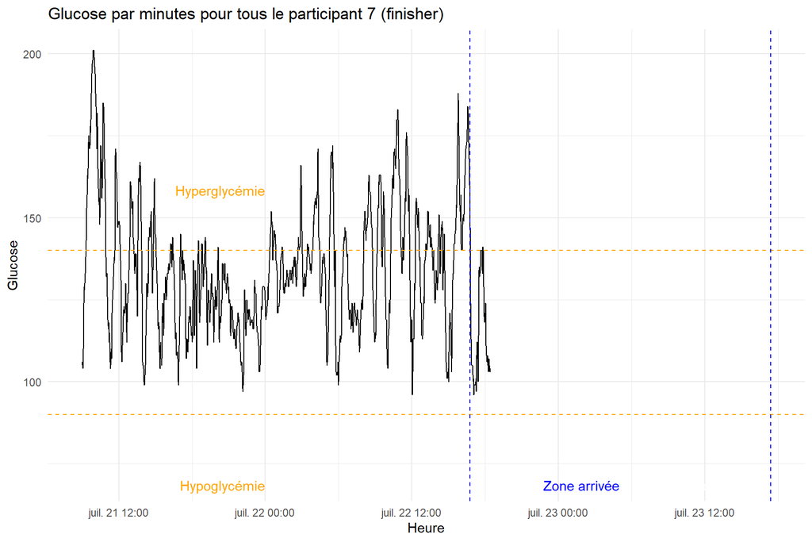

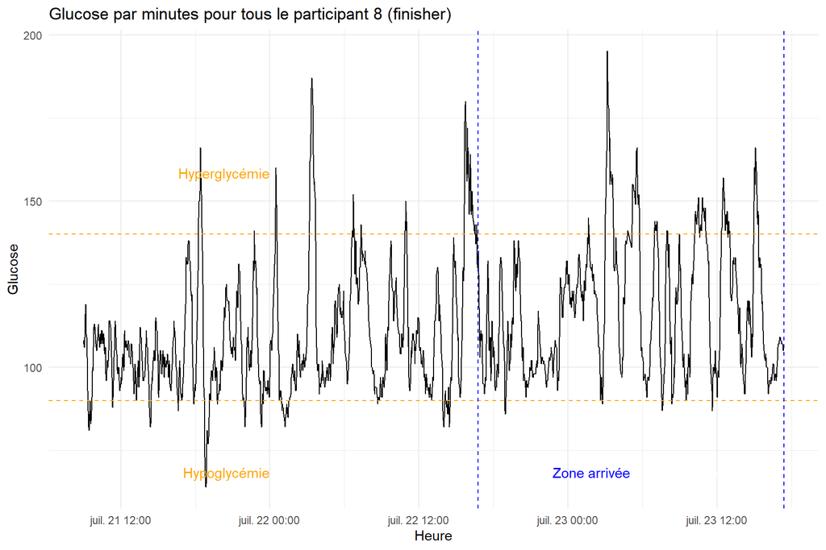

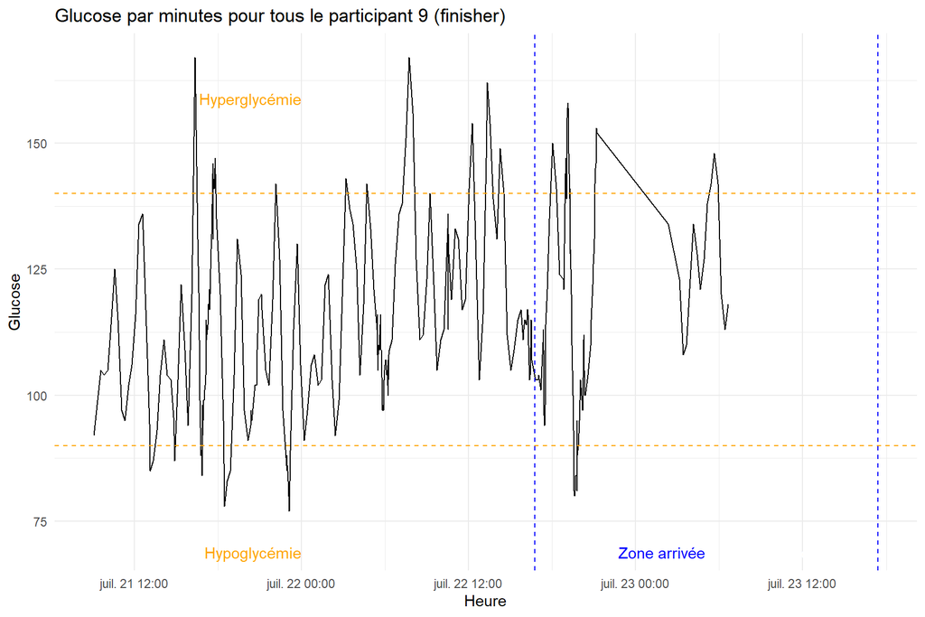

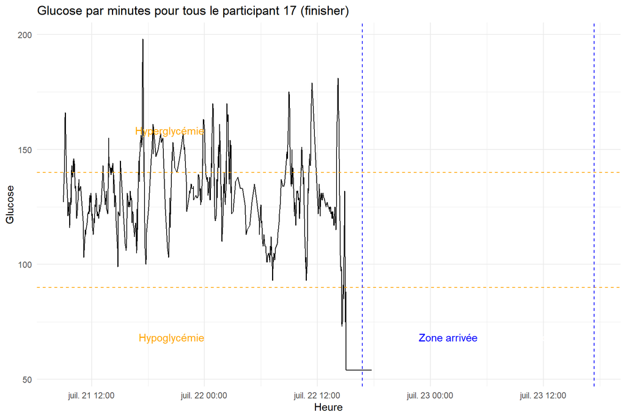

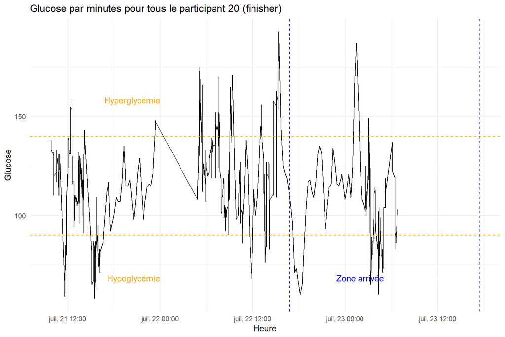

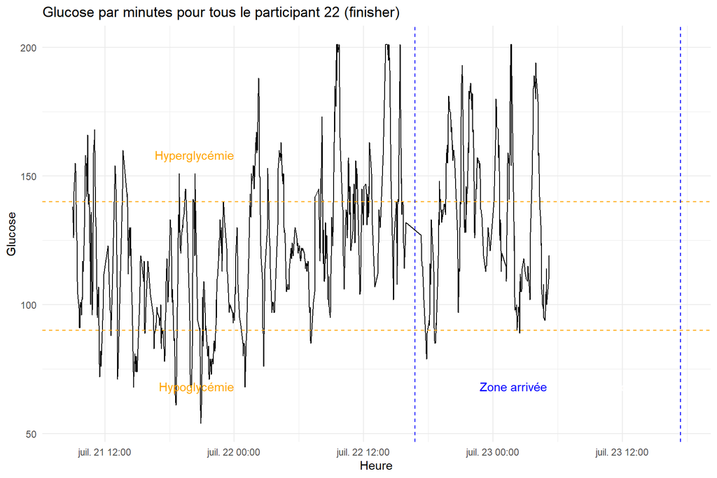

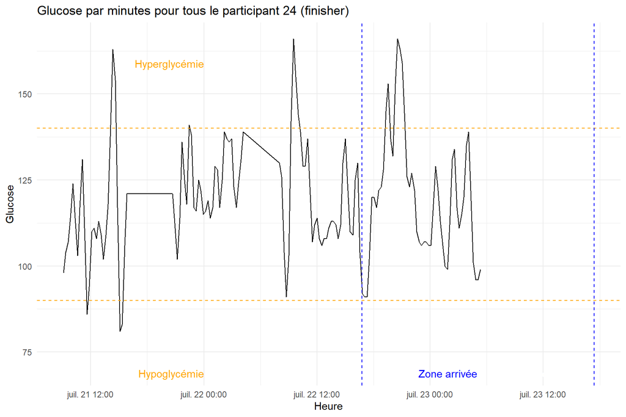

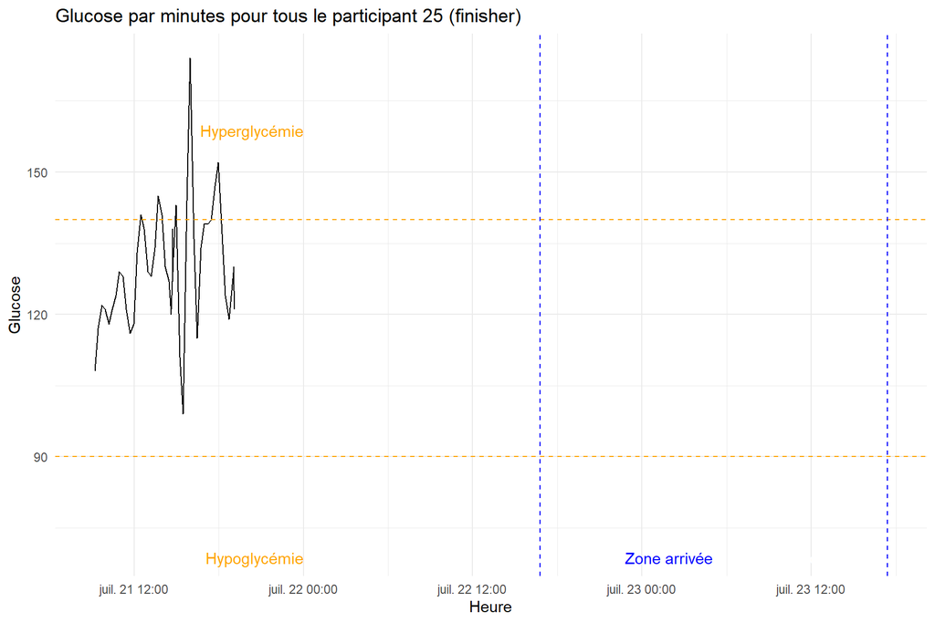

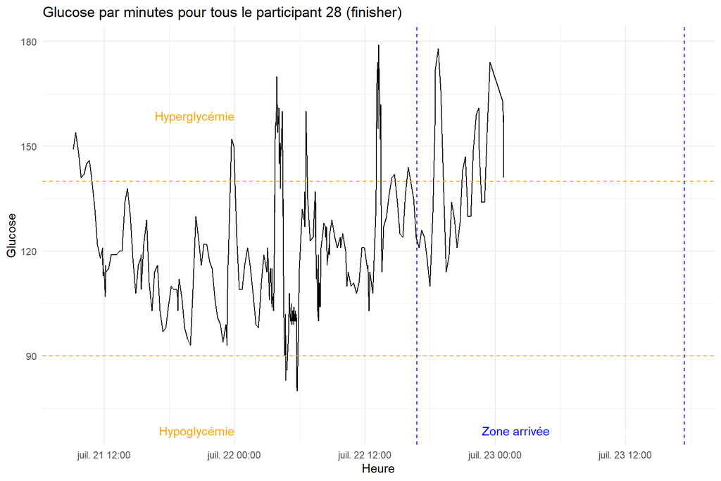

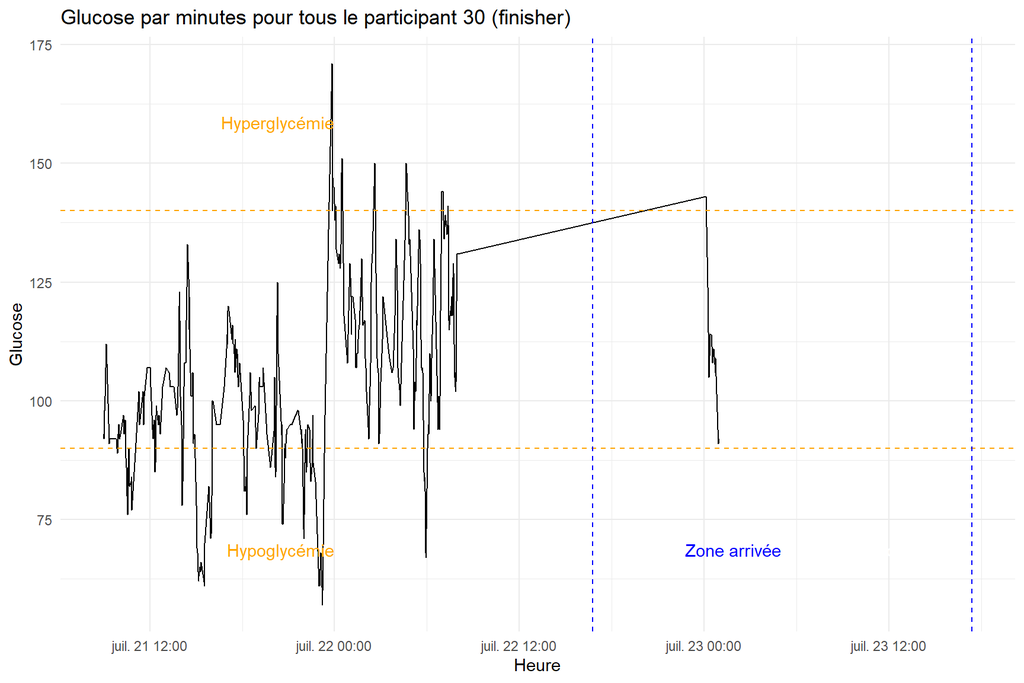

[1 more figures not shown]